# Monte Carlo Integration and Variance Reduction

## Q1)

Assume that you have a biased coin, and you want to simulate tossing an unfair coin experiment to see how law of large numbers works. In this experiment probability of turning up heads is 0.7.

**a)** Simulate the proportions of turning on heads by taking sample size n=1000. You are only allowed to use uniform random number generator.

**b)** Try to obtain plot below. (On the y-axis, the proportions of the heads should be, and on the x-axis, how many times did you continue this experiment namely, number of replicates.)

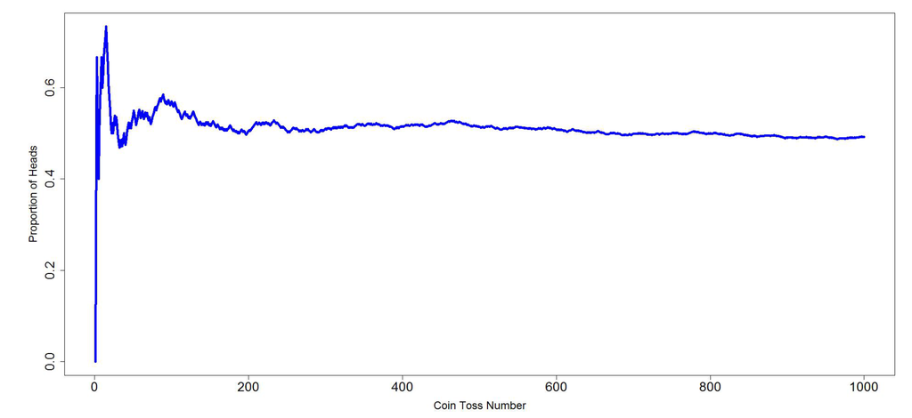

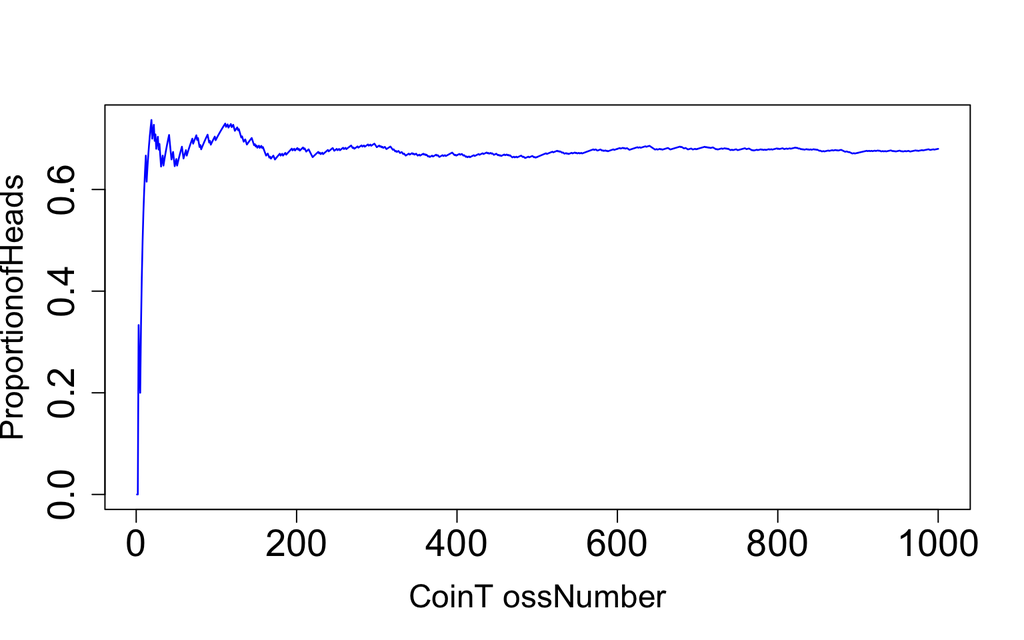

```r
n = 10^3;
U = runif(n, min = 0, max = 1);
toss = U < 0.7;
a = numeric(n + 1);
avg = numeric(n);

for(i in 2 : n + 1){
  a[i] = a[i - 1] + toss[i - 1];
  avg[i - 1] = a[i]/(i - 1);
}


plot(1 : n, avg[1 : n], type = "l", lwd = 1.3, col = "blue", ylab = "ProportionofHeads",
     xlab = "CoinT ossNumber", cex.main = 1.25, cex.lab = 1.5, cex.axis = 1.75)
```

## Q2)

Generate a sample from Gamma(2, 1) distribution conditional on its value being greater than 5, that is

$$f(x) = \frac{xe^{-x}}{\int_5^{\infty}xe^{-x}dx}$$
Using rejection sampling.

(Hint: Assume g(x) be the density function of exponential distribution.)

Since Gamma(2,1) random variable has expected value 2, we use an exponential distribution with mean 2 that is conditioned to be greater than 5.

$$f(x) = \frac{xe^{-x}}{\int_5^{\infty}xe^{-x}dx} = \frac{xe^{-x}}{6e^{-5}}\ (5 \leq x)$$

$$g(x) = \frac{\frac{1}{2}e^\frac{-x}{2}}{e^\frac{-5}{2}}\ (5 \leq x)$$
$$\frac{f(x)}{g(x)}= \frac{x}{3}e^{\frac{-(x-5)}{2}}$$

We obtain the maximum in x = 5 since $\frac{f(x)}{g(x)}$ is decreasing. Therefore,

$$c= \frac{f(5)}{g(5)}=\frac{5}{3}$$

- Generate a random variable Y distributed as G(Y)
- Generate random variable U
- If U < $\frac{x}{5}e^{\frac{-(x-5)}{2}}$ accept set Y=X, otherwise go back to step 1.

```r
set.seed(2022)  # for reproducibility
n = 10^4        # sample size
i <- 0  # number of iteration
k <- 0 # counter for accepted
y <- numeric(n) # random sample
c <- 5/3


while (k < n) {
  u = runif(1)
  i <- i+1
  x = 5 - 2*log(runif(1))
  if (u <= (x/5) * exp(-(x-5)/2 * c)) {
    k <- k + 1
    y[k] <- x
  }
}
i;k;length(y)
```

```
## [1] 23205
```

```
## [1] 10000
```

```
## [1] 10000
```

```r
summary(y)
```

```
##    Min. 1st Qu.  Median    Mean 3rd Qu.    Max.
##   5.000   5.249   5.597   5.846   6.182  11.566
```

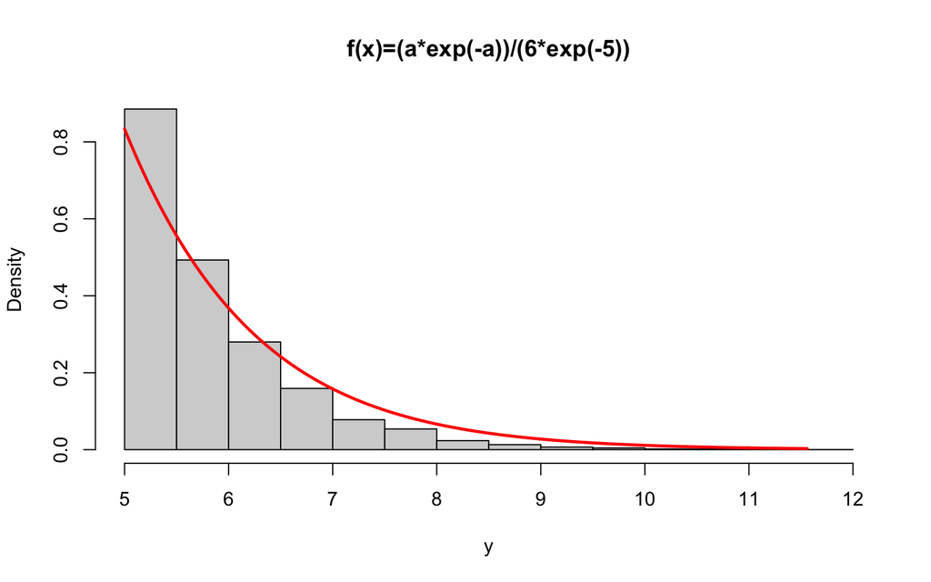

```r
hist(y, prob = TRUE, main ="f(x)=(a*exp(-a))/(6*exp(-5))")
a = seq(min(y), max(y), 0.01)
lines(a, (a*exp(-a))/(6*exp(-5)), col="red",lwd = 2.5)
```

## Q3)

Let $X \sim Cauchy(\mu,s)$ and let p be a real number. You want to approximate the probability $P(X < p_1)+P(x > p_2)$, by taking $\mu=-2$, $s=4$ and $p_1= 0.9$ and $p_2=3$.

PDF of Cauchy Distribution;

$$f(x)=\frac{1}{\pi s[1+ (\frac{x-\mu}{s})^2]},\ \text{where s>0 and x€}(-\infty,\infty)$$

CDF of Cauchy Distribution;

$$\int_{-\infty}^{\infty} \frac{1}{\pi s[1+ (\frac{x-\mu}{s})^2]},\ \text{where s>0 and x€}(-\infty,\infty)$$

Approximate this integral using classical Monte Carlo Integration and calculate variance of the estimator.

```r
set.seed(361)

# Step 1: Define f(X)

f <- function(x) function(x, s, mu){ 1/pi*s*(1+((x-mu)/s)^2)}


# Step 2: Define g(X)

g1 <- function(x, p1){
  if (x < p1) return(1)
  else return(0)
}


g2 <- function(x, p2){
  if (x > p2) return(1)
  else return(0)
}

# Step 3: Generate x1,...,xn  iid random variables

n <-10^5
mu <- -2
s <- 4
p1 <- 0.9
p2 <- 3

x <- rcauchy(n = n, scale= s, location  = mu)


# Step 4: Compute the estimate

probability1 = mean(sapply(x ,g1, p1))
probability2 = mean(sapply(x ,g2, p2))

estimate_classical = probability1 + probability2


cat("Estimated P(x < 0.9) + P(x > 3) =", estimate_classical,"\n")
```

```
## Estimated P(x < 0.9) + P(x > 3) = 0.91396
```

```r
cat("Real probability value is:",pcauchy(p1, location = mu, scale = s) + (1- pcauchy(p2, location = mu, scale = s)),"\n")
```

```
## Real probability value is: 0.9144551
```

```r
var_prob1 <- (mean(sapply(x ,g1, p1)^2) - (mean(sapply(x ,g1, p1)))^2) # Var(x) = E(X^2) - E(x)^2
var_prob2 <- (mean(sapply(x ,g2, p2)^2) - (mean(sapply(x ,g2, p2)))^2) # Var(x) = E(X^2) - E(x)^2


var_cauchy <- var_prob1 + var_prob2 + 2*cov(sapply(x ,g1, p1), sapply(x ,g1, p1))

cat("Variance of classical monte carlo is:" , var_cauchy)
```

```
## Variance of classical monte carlo is: 0.8001827
```